# Réorganisation des données - solution des exercices

[Retour à la page d’accueil](https://scortijo.github.io/2021_L3_R/)

> **Exercice 1** : Sélectionnez les colonnes qui contiennent des données mesurées en mm

```r
select(expt1, contains("mm"))
```

```
## # A tibble: 957 x 2
##    blade.length.mm total.leaf.length.mm
##              <dbl>                <dbl>
##  1            12.9                 21.1
##  2            10.5                 19.1
##  3            13.2                 23.4
##  4            14.6                 27.2
##  5            13.3                 20.4
##  6            14.7                 25.3
##  7            13                   23.2
##  8            17.8                 31.3
##  9            20.7                 33.1
## 10            19.4                 33.2
## # … with 947 more rows
```

> **Exercice 2:** Filtrez les données pour garder les plantes selon les 3 cas de figures suivant (indépendants les uns des autres):
> 1. Plantes qui **ne sont pas du background Ler** et qui ont été traitées avec **une température fluctuante**.
> 2. Plantes qui ont fleuries (bolt) en moins de **57 jours** et qui ont **moins de 40 feuilles de rosette**
> 3. Plantes du génotype **fca-6** pour qui le **blade.ratio n’est pas manquant**

```r
# 1. Filtrez les plantes qui ne sont pas du background Ler et qui ont été traitées avec une température fluctuante.

filter(expt1, background!="Ler" & fluctuation=="Var")
```

```
## # A tibble: 389 x 15
##    plant_nb genotype background temperature fluctuation day.length vernalization
##       <dbl> <chr>    <chr>            <dbl> <chr>            <dbl> <chr>
##  1        1 Col Ama  Col                 12 Var                 16 NV
##  2        2 Col Ama  Col                 12 Var                 16 NV
##  3        3 Col Ama  Col                 12 Var                 16 NV
##  4        4 Col Ama  Col                 12 Var                 16 NV
##  5        5 Col Ama  Col                 12 Var                 16 NV
##  6        6 Col Ama  Col                 12 Var                 16 NV
##  7        7 Col Ama  Col                 12 Var                 16 NV
##  8        8 Col Ama  Col                 12 Var                 16 NV
##  9        1 Col Ama  Col                 12 Var                  8 NV
## 10        2 Col Ama  Col                 12 Var                  8 NV
## # … with 379 more rows, and 8 more variables: survival.bolt <chr>, bolt <chr>,
## #   days.to.bolt <dbl>, days.to.flower <dbl>, rosette.leaf.num <dbl>,
## #   cauline.leaf.num <dbl>, blade.length.mm <dbl>, total.leaf.length.mm <dbl>
```

```r
# 2. Filtrez les plantes qui ont fleuries (bolt) en moins de  57 jours et qui ont moins de 40 feuilles.

filter(expt1, days.to.bolt<57  & rosette.leaf.num<40)
```

[output not shown]

```r
# 3. Filtrez les plantes du génotype fca-6 pour qui le blade.length.mm n'est pas manquant

filter(expt1, genotype=="fca-6"  & !is.na(blade.length.mm))
```

```
## # A tibble: 44 x 15
##    plant_nb genotype background temperature fluctuation day.length vernalization
##       <dbl> <chr>    <chr>            <dbl> <chr>            <dbl> <chr>
##  1        1 fca-6    Ler                 12 Con                 16 NV
##  2        2 fca-6    Ler                 12 Con                 16 NV
##  3        3 fca-6    Ler                 12 Con                 16 NV
##  4        4 fca-6    Ler                 12 Con                 16 NV
##  5        5 fca-6    Ler                 12 Con                 16 NV
##  6        6 fca-6    Ler                 12 Con                 16 NV
##  7        7 fca-6    Ler                 12 Con                 16 NV
##  8        8 fca-6    Ler                 12 Con                 16 NV
##  9        1 fca-6    Ler                 12 Con                  8 NV
## 10        2 fca-6    Ler                 12 Con                  8 NV
## # … with 34 more rows, and 8 more variables: survival.bolt <chr>, bolt <chr>,
## #   days.to.bolt <dbl>, days.to.flower <dbl>, rosette.leaf.num <dbl>,
## #   cauline.leaf.num <dbl>, blade.length.mm <dbl>, total.leaf.length.mm <dbl>
```

> **Exercice 3:** Utilisez `%>%` pour faire la suite de sélections suivantes sur`expt1`:
> - Gardez les plantes qui *ne sont pas* du background Ler, et qui ont été traitées avec la température fluctuante.
> - Ne gardez que les colonnes qui contiennent le génotype, la longueur de “blade” et des information sur le “bolting” (aide: utilisez `contains()`)

```r
filter(expt1,  background!="Ler" & fluctuation=="Var") %>%
  select(genotype, blade.length.mm, contains("bolt"))
```

```
## # A tibble: 389 x 5
##    genotype blade.length.mm survival.bolt bolt  days.to.bolt
##    <chr>              <dbl> <chr>         <chr>        <dbl>
##  1 Col Ama             15.1 Y             Y               32
##  2 Col Ama             16   Y             Y               32
##  3 Col Ama             17.5 Y             Y               32
##  4 Col Ama             15.1 Y             Y               33
##  5 Col Ama             15   Y             Y               33
##  6 Col Ama             15.1 Y             Y               33
##  7 Col Ama             13.7 Y             Y               33
##  8 Col Ama             17.7 Y             Y               33
##  9 Col Ama             29.7 Y             Y               68
## 10 Col Ama             22.1 Y             Y               68
## # … with 379 more rows
```

> **Exercice 4:** Faite un violon plot du temps de floraison pour les différents génotypes, mais uniquement pour les plantes ayant poussées en jours court (8h de lumière).

> Aide: Utilisez `filter()` pour sélectionner les données et ensuite un pipe (`%>%`) pour utiliser l’output pour le graphique.

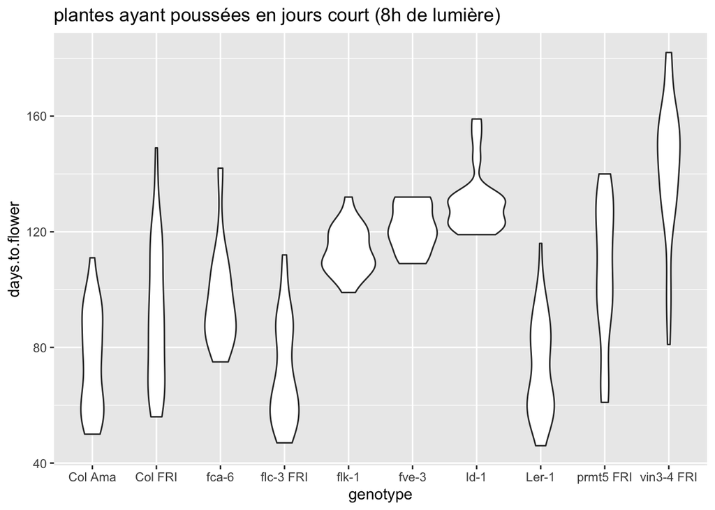

```r
filter(expt1,  day.length==8) %>%
  ggplot((aes( x=genotype, y=days.to.flower))) +
  geom_violin() +
  ggtitle("plantes ayant poussées en jours court (8h de lumière)")
```

> **BONUS**

> Représentez, uniquement pour les plantes qui contiennent le mot “Col” dans le background, et qui ont poussée à 22°C, un box plot de *days.to.bolt* en fonction du *day.length*, coloré en fonction de la *fluctuation*. Séparez les graphiques pour avoir une facet par *génotype*. Utilisez un thème de type *theme_bw*.

> Interprétez le résultat: Est-ce que le temps de floraison de certains génotypes est affecté par la fluctuation de température. Si oui lesquels?

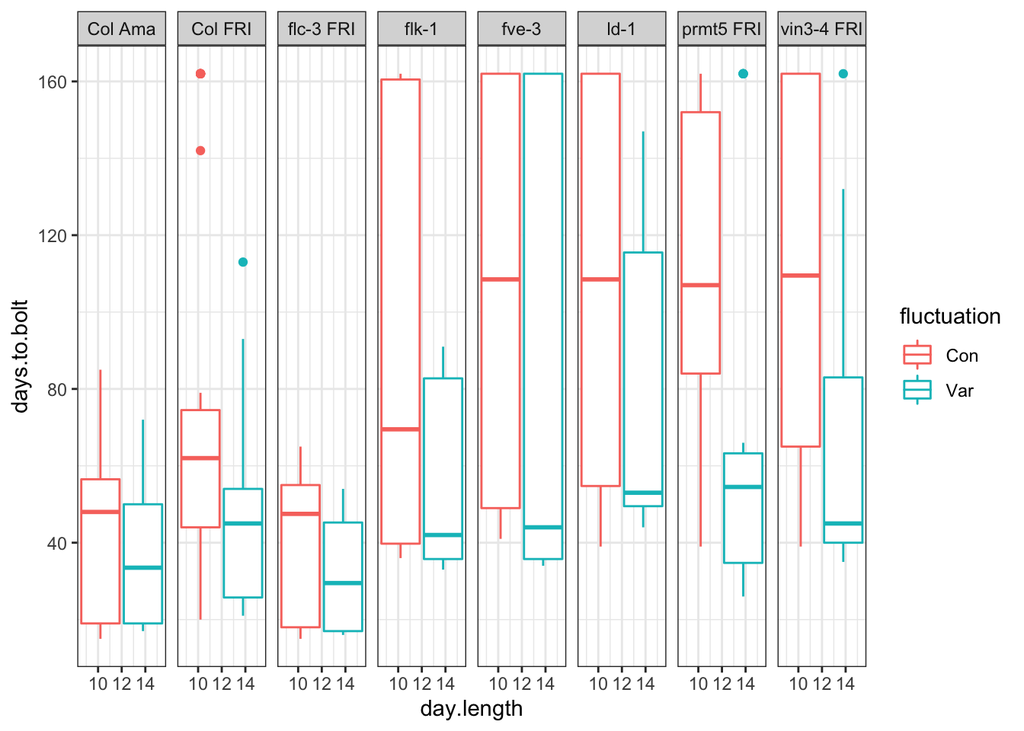

```r
filter(expt1, grepl("Col", background) & temperature == 22) %>%
  ggplot(aes(x=day.length, y=days.to.bolt, color=fluctuation)) +
  geom_boxplot()+
  facet_grid(.~genotype) +
  theme_bw()
```